# Analysis_Toothgrowth

Julian Jang

October 25, 2015

## Analysis of Toothgrowth dataset

### Overview(Summary)

#### The explanation of ‘Toothgrowth’ dataset is below. This dataset is a data show that the effect of Vitamin C on Tooth Growth in Guinea Pigs. The response is the length of odontoblasts (teeth) in each of 10 guinea pigs at each of three dose levels of Vitamin C (0.5, 1, and 2 mg) with each of two delivery methods (orange juice or ascorbic acid).

- len : numeric value for Tooth length
- supp : factor value for Supplement type (VC or OJ).
- dose : numeric value for Dose in milligrams.

### Basic EDA

I looked through the dataset with boxplots. I made boxplots to find out the difference of length through supplement methods and amount of dosage. The results are below. I glanced, I think that the difference existed in each control group.

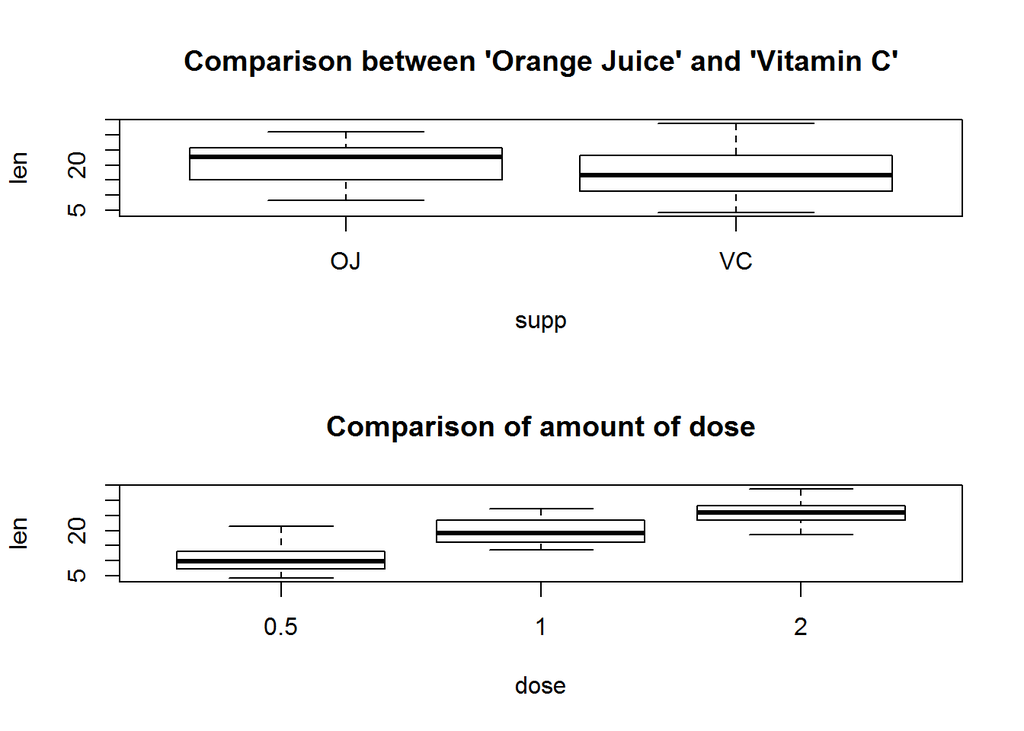

```r
ToothGrowth$dose <- as.factor(ToothGrowth$dose)
par(mfrow = c(2, 1))
plot(len ~ supp, data = ToothGrowth, main = "Comparison between 'Orange Juice' and 'Vitamin C'")
plot(len ~ dose, data = ToothGrowth, main = "Comparison of amount of dose")
```

```r
with(ToothGrowth, tapply(len, supp, mean))
```

```
##       OJ       VC
## 20.66333 16.96333
```

```r
with(ToothGrowth, tapply(len, dose, mean))
```

```
##    0.5      1      2
## 10.605 19.735 26.100
```

### t test for groups which are divied accordingly supplement method.

I divided the dataset into two parts-‘VC’ and ‘OJ’. I used two external packages(‘tidyr’, ‘dplyr’). And, I t tested. The result of t test is that No difference between ‘VC’ and ‘OJ’. The p-value is ‘0.06063’. So, I can’t deny Null hypothesis because that my p-value is greater than 0.05 I can’t deny Null hypothesis.

```r
if (!require(tidyr)) { install.packages("tidyr") }
if (!require(dplyr)) { install.packages("dplyr") }

Supp.df <- ToothGrowth %>% select(supp, len) %>% spread(supp, len)
with(Supp.df, t.test(VC, OJ))
```

```
##
##  Welch Two Sample t-test
##
## data:  VC and OJ
## t = -1.9153, df = 55.309, p-value = 0.06063
## alternative hypothesis: true difference in means is not equal to 0
## 95 percent confidence interval:
##  -7.5710156  0.1710156
## sample estimates:
## mean of x mean of y
##  16.96333  20.66333
```

### t test for comparison among the amount of dose.

I executed t.test to compare difference of length by amount of dose in same way. I tested 3 times for 3 groups. In summary, The length was different according to amount of dose. ‘0.5 & 1.0’, ‘0.5 & 2.0’ and ‘1.0 & 2.0’ were all different in mean value. The results of t tests are below.

```r
Dose.df <- ToothGrowth %>% select(dose, len) %>% spread(dose, len)
names(Dose.df) <- c("a_0.5", "a_1", "a_2")

Dose.t_1 <- with(Dose.df, t.test(a_0.5, a_1))
Dose.t_1$p.value
```

```
## [1] 1.268301e-07
```

```r
Dose.t_1$conf.int
```

```
## [1] -11.983781  -6.276219
## attr(,"conf.level")
## [1] 0.95
```

```r
Dose.t_2 <- with(Dose.df, t.test(a_0.5, a_2))
Dose.t_2$p.value
```

```
## [1] 4.397525e-14
```

```r
Dose.t_2$conf.int
```

```
## [1] -18.15617 -12.83383
## attr(,"conf.level")
## [1] 0.95
```

```r
Dose.t_3 <- with(Dose.df, t.test(a_1, a_2))
Dose.t_3$p.value
```

```
## [1] 1.90643e-05
```

```r
Dose.t_3$conf.int
```

```
## [1] -8.996481 -3.733519
## attr(,"conf.level")
## [1] 0.95
```

### Conclusion

- Null Hypothesis: The length of tooth will have no diffrence according to dose method and amount of Vitamin C.
- Alternative Hypothesis: The length of tooth will diffrent according to dose method and amount of Vitamin C.

The result of test.

- No difference on dose methods.
- Amount of dose causes difference of length of tooth.